# Codebook for Replication study of Kerwer et al.(2020)

Here, we’re just setting a few options.

```r
knitr::opts_chunk$set(
  warning = TRUE, # show warnings during codebook generation
  message = TRUE, # show messages during codebook generation
  error = TRUE, # do not interrupt codebook generation in case of errors,
                # usually better for debugging
  echo = TRUE  # show R code
)
ggplot2::theme_set(ggplot2::theme_bw())
```

Now, we’re preparing our data for the codebook.

```r
library(tidyverse)
library(codebook)
codebook_data <- codebook::bfi
# to import an SPSS file from the same folder uncomment and edit the line below
# codebook_data <- rio::import("mydata.sav")
# for Stata
# codebook_data <- rio::import("mydata.dta")
# for CSV

## locate the rawdata file
zip_path <- list.files(path = "..",pattern = "jatos_results.zip",include.dirs = TRUE,recursive = TRUE,full.names = TRUE)
## import rawdata from zip file
df <- read_csv(unz(zip_path, filename = "rawdata.csv"))

## import text id table; script did not log text_id
text <- readr::read_csv("../4_OS_Result/text_id.csv")

## Extract the system variables
df_sys <- select(df, starts_with(c("identifier","jatos","browser_","count_","date_","experiment_","screen_","system_","Start ","Last ","Duration","Batch","Worker ","State","Message")))

## Reserve the analytical variables in rawdata df
df <- select(df, !names(df_sys)[-c(1,2)])

## Split basic data
df_Basic <- filter(df, Q_type == "Basic")

## Exclude the variables full of "None"
df_Basic <- df_Basic[,which(colSums(df_Basic!="None",na.rm = TRUE) != 0)]

## Split Belief data
df_Belief <- filter(df, Q_type == "Belief")
## Exclude the variables full of "None"
df_Belief <- df_Belief[,which(colSums(df_Belief!="None",na.rm = TRUE) != 0)]


## Split self evaluation data
df_self_eval <- filter(df, Q_type == "self_eval")
## Exclude the variables full of "None"
df_self_eval <- df_self_eval[,which(colSums(df_self_eval!="None",na.rm = TRUE) != 0)]

## Split post reading Question data
df_Post <- dplyr::filter(df, Q_type == "Post_survey") %>% left_join(text, by= "Content")
## Exclude the variables full of "None"
df_Post <- df_Post[,which(colSums(df_Post!="None",na.rm = TRUE) != 0)] %>% mutate(Text_id = as.character(Text_id))

## Split knowledge data
df_knowledge <- filter(df, Q_type == "Knowledge")
## Exclude the variables full of "None"
df_knowledge <- left_join(dplyr::select(df_knowledge[,which(colSums(df_knowledge!="None",na.rm = TRUE) != 0)], -c("NH","OSA","text_order")), ## Erase IV variables because they are meaningless in test loop
  dplyr::select(df_Post, jatosStudyResultId, NH, OSA, Text_id, text_order) %>% distinct(),## Extract IV variables from df_Post
by=c("jatosStudyResultId","Test_id"="Text_id")) ## Add IV vriables to df_knowledge by Test_id

## Split Exit
df_Exit <- filter(df, Q_type == "Exit")
## Exclude the variables full of "None"
df_Exit <- df_Exit[,which(colSums(df_Exit!="None",na.rm = TRUE) != 0)]

# omit the following lines, if your missing values are already properly labelled
#codebook_data <- detect_missing( df, #codebook_data,
#    only_labelled = TRUE, # only labelled values are autodetected as
                                   # missing
#    negative_values_are_missing = FALSE, # negative values are missing values
#    ninety_nine_problems = TRUE,   # 99/999 are missing values, if they
                                   # are more than 5 MAD from the median
#    )

# If you are not using formr, the codebook package needs to guess which items
# form a scale. The following line finds item aggregates with names like this:
# scale = scale_1 + scale_2R + scale_3R
# identifying these aggregates allows the codebook function to
# automatically compute reliabilities.
# However, it will not reverse items automatically.
#codebook_data <- detect_scales(df)
```

Manage the variable labels and scales

```r
library(labelled)
#codebook_data$
```

## codebook: basic questions

```r
codebook(df_Basic,metadata_table = FALSE, metadata_json = FALSE)
```

### Metadata

#### Description

**Dataset name**: df_Basic

The dataset has N=300 rows and 5 columns. 299 rows have no missing values on any column.

**Metadata for search engines**

- **Date published**: 2022-04-19

| x |
| --- |
| Q_type |
| Topic |
| identifier |
| jatosStudyResultId |
| response |

#Variables

### Q_type

#### Distribution

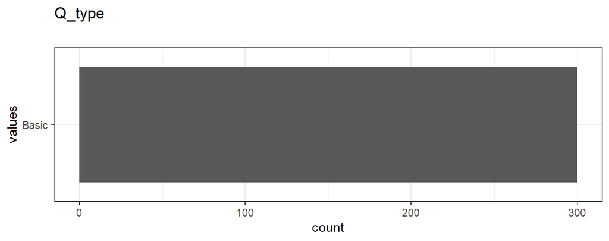

Distribution of values for Q_type

0 missing values.

#### Summary statistics

| name | data_type | n_missing | complete_rate | n_unique | empty | min | max | whitespace | label |
| --- | --- | --- | --- | --- | --- | --- | --- | --- | --- |
| Q_type | character | 0 | 1 | 1 | 0 | 5 | 5 | 0 | NA |

### Topic

#### Distribution

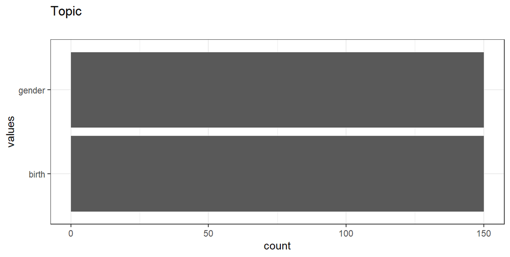

Distribution of values for Topic

0 missing values.

#### Summary statistics

| name | data_type | n_missing | complete_rate | n_unique | empty | min | max | whitespace | label |
| --- | --- | --- | --- | --- | --- | --- | --- | --- | --- |
| Topic | character | 0 | 1 | 2 | 0 | 5 | 6 | 0 | NA |

### identifier

#### Distribution

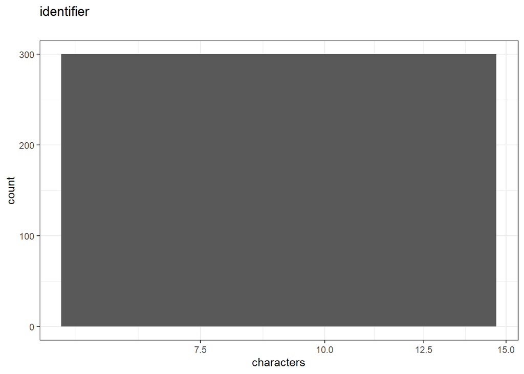

Distribution of values for identifier

0 missing values.

#### Summary statistics

| name | data_type | n_missing | complete_rate | n_unique | empty | min | max | whitespace | label |
| --- | --- | --- | --- | --- | --- | --- | --- | --- | --- |
| identifier | character | 0 | 1 | 150 | 0 | 9 | 9 | 0 | NA |

### jatosStudyResultId

#### Distribution

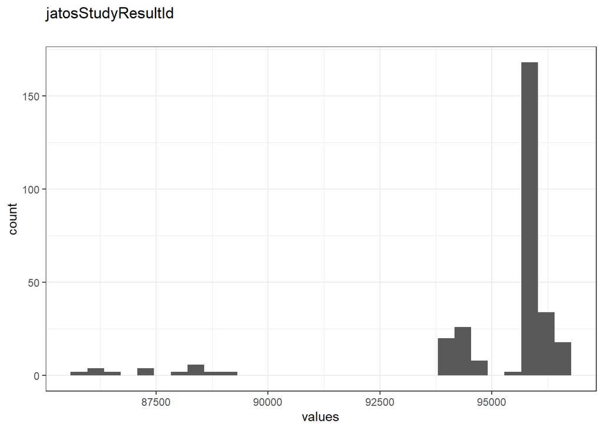

Distribution of values for jatosStudyResultId

0 missing values.

#### Summary statistics

| name | data_type | n_missing | complete_rate | min | median | max | mean | sd | hist | label |
| --- | --- | --- | --- | --- | --- | --- | --- | --- | --- | --- |
| jatosStudyResultId | numeric | 0 | 1 | 85756 | 95744 | 96571 | 94925.99 | 2312.289 | ▁▁▁▂▇ | NA |

### response

#### Distribution

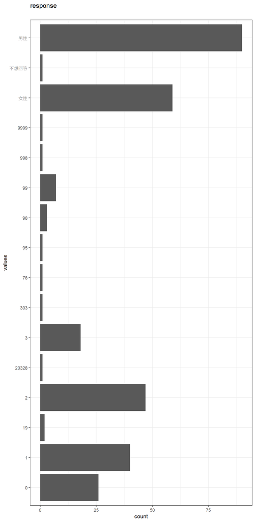

Distribution of values for response

1 missing values.

#### Summary statistics

| name | data_type | n_missing | complete_rate | n_unique | empty | min | max | whitespace | label |
| --- | --- | --- | --- | --- | --- | --- | --- | --- | --- |
| response | character | 1 | 0.9966667 | 16 | 0 | 1 | 5 | 0 | NA |

## Missingness report

[output not shown]

## codebook: beleif

```r
codebook(df_Belief,metadata_table = FALSE, metadata_json = FALSE)
```

### Metadata

#### Description

**Dataset name**: df_Belief

The dataset has N=1350 rows and 6 columns. 1350 rows have no missing values on any column.

**Metadata for search engines**

- **Date published**: 2022-04-19

| x |
| --- |
| Q_type |
| Question |
| Topic |
| identifier |
| jatosStudyResultId |
| response |

#Variables

### Q_type

#### Distribution

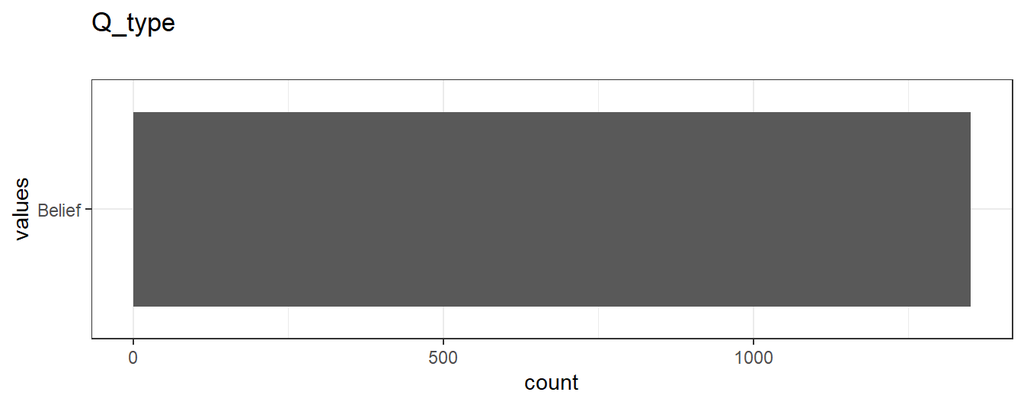

Distribution of values for Q_type

0 missing values.

#### Summary statistics

| name | data_type | n_missing | complete_rate | n_unique | empty | min | max | whitespace | label |
| --- | --- | --- | --- | --- | --- | --- | --- | --- | --- |
| Q_type | character | 0 | 1 | 1 | 0 | 6 | 6 | 0 | NA |

### Question

#### Distribution

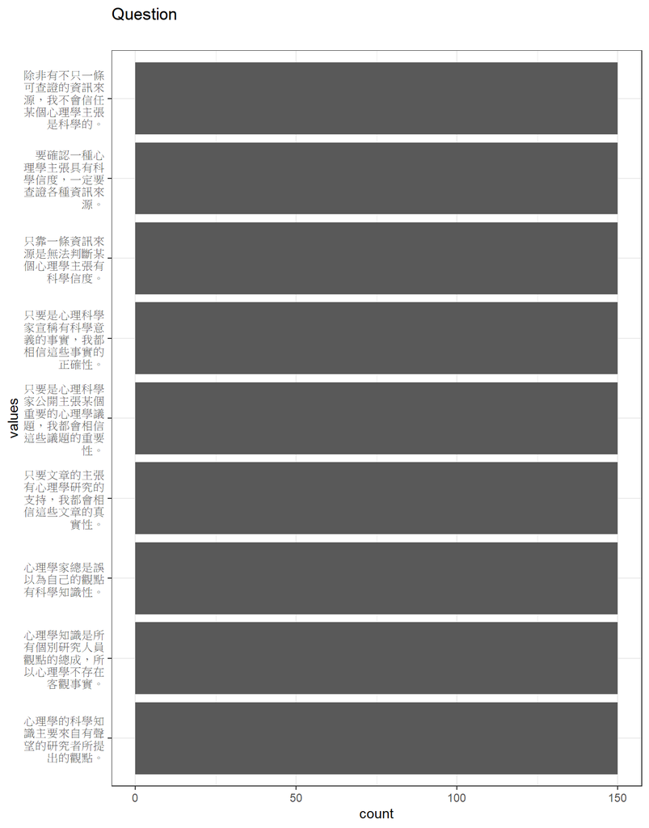

Distribution of values for Question

0 missing values.

#### Summary statistics

| name | data_type | n_missing | complete_rate | n_unique | empty | min | max | whitespace | label |
| --- | --- | --- | --- | --- | --- | --- | --- | --- | --- |
| Question | character | 0 | 1 | 9 | 0 | 21 | 37 | 0 | NA |

### Topic

#### Distribution

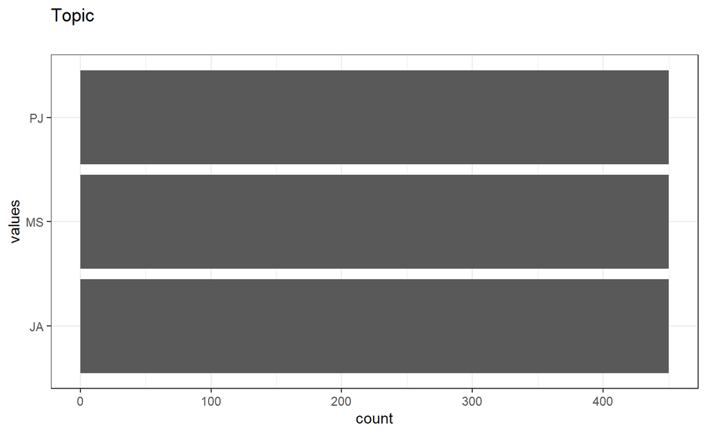

Distribution of values for Topic

0 missing values.

#### Summary statistics

| name | data_type | n_missing | complete_rate | n_unique | empty | min | max | whitespace | label |
| --- | --- | --- | --- | --- | --- | --- | --- | --- | --- |
| Topic | character | 0 | 1 | 3 | 0 | 2 | 2 | 0 | NA |

### identifier

#### Distribution

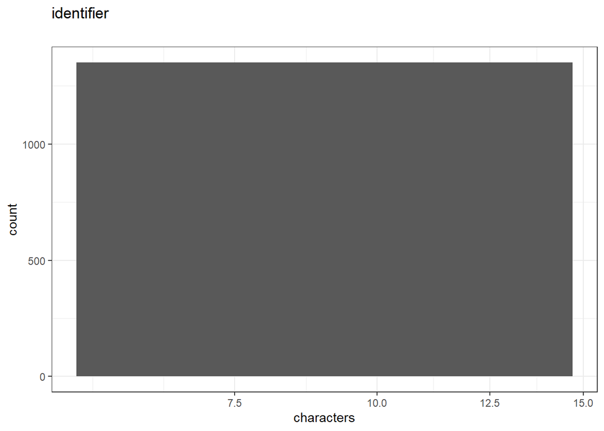

Distribution of values for identifier

0 missing values.

#### Summary statistics

| name | data_type | n_missing | complete_rate | n_unique | empty | min | max | whitespace | label |
| --- | --- | --- | --- | --- | --- | --- | --- | --- | --- |
| identifier | character | 0 | 1 | 150 | 0 | 9 | 9 | 0 | NA |

### jatosStudyResultId

#### Distribution

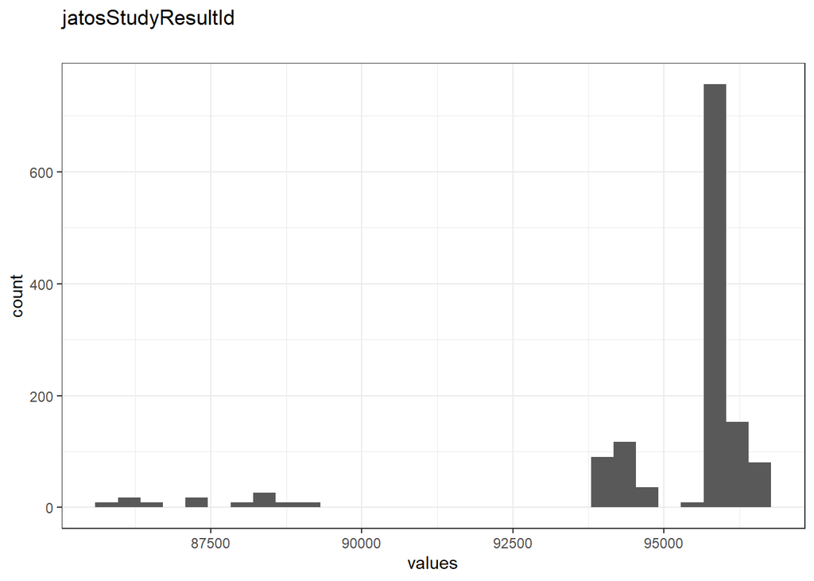

Distribution of values for jatosStudyResultId

0 missing values.

#### Summary statistics

| name | data_type | n_missing | complete_rate | min | median | max | mean | sd | hist | label |
| --- | --- | --- | --- | --- | --- | --- | --- | --- | --- | --- |
| jatosStudyResultId | numeric | 0 | 1 | 85756 | 95744 | 96571 | 94925.99 | 2309.287 | ▁▁▁▂▇ | NA |

### response

#### Distribution

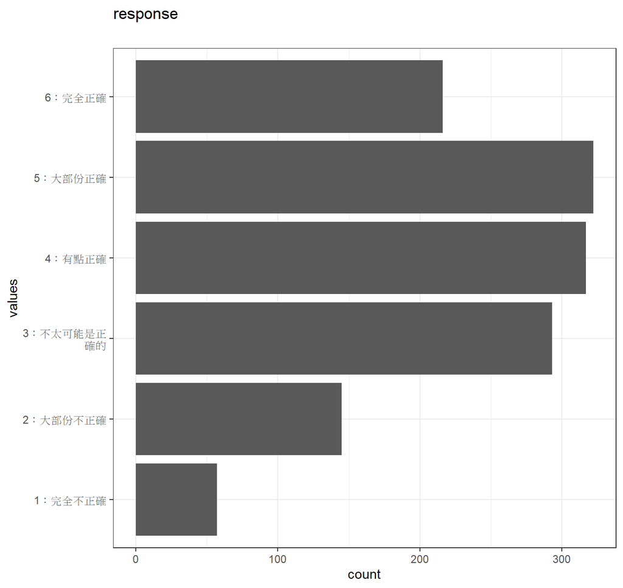

Distribution of values for response

0 missing values.

#### Summary statistics

| name | data_type | n_missing | complete_rate | n_unique | empty | min | max | whitespace | label |
| --- | --- | --- | --- | --- | --- | --- | --- | --- | --- |
| response | character | 0 | 1 | 6 | 0 | 6 | 10 | 0 | NA |

## Missingness report

## codebook: self evaluation

```r
codebook(df_self_eval,metadata_table = FALSE, metadata_json = FALSE)
```

### Metadata

#### Description

**Dataset name**: df_self_eval

The dataset has N=300 rows and 6 columns. 300 rows have no missing values on any column.

**Metadata for search engines**

- **Date published**: 2022-04-19

| x |
| --- |
| Q_type |
| Question |
| Topic |
| identifier |
| jatosStudyResultId |
| response |

#Variables

### Q_type

#### Distribution

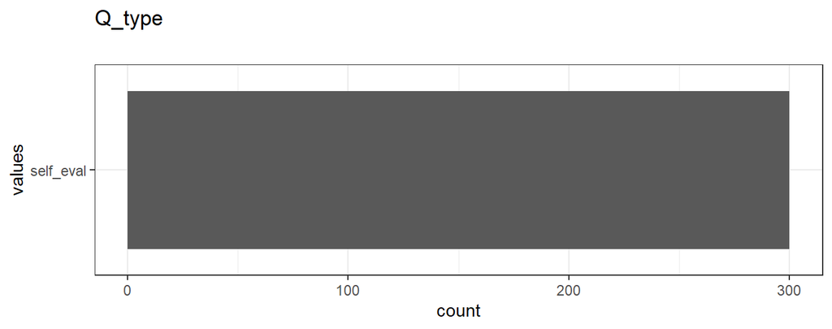

Distribution of values for Q_type

0 missing values.

#### Summary statistics

| name | data_type | n_missing | complete_rate | n_unique | empty | min | max | whitespace | label |
| --- | --- | --- | --- | --- | --- | --- | --- | --- | --- |
| Q_type | character | 0 | 1 | 1 | 0 | 9 | 9 | 0 | NA |

### Question

#### Distribution

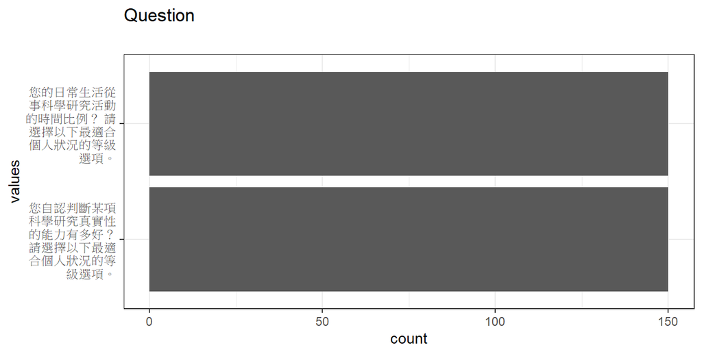

Distribution of values for Question

0 missing values.

#### Summary statistics

| name | data_type | n_missing | complete_rate | n_unique | empty | min | max | whitespace | label |
| --- | --- | --- | --- | --- | --- | --- | --- | --- | --- |
| Question | character | 0 | 1 | 2 | 0 | 39 | 40 | 0 | NA |

### Topic

#### Distribution

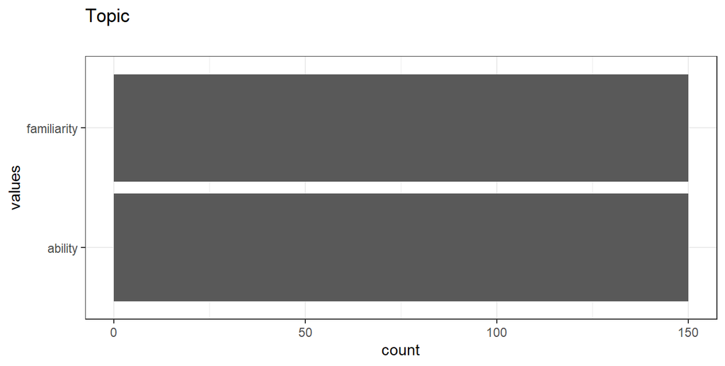

Distribution of values for Topic

0 missing values.

#### Summary statistics

| name | data_type | n_missing | complete_rate | n_unique | empty | min | max | whitespace | label |
| --- | --- | --- | --- | --- | --- | --- | --- | --- | --- |
| Topic | character | 0 | 1 | 2 | 0 | 7 | 11 | 0 | NA |

### identifier

#### Distribution

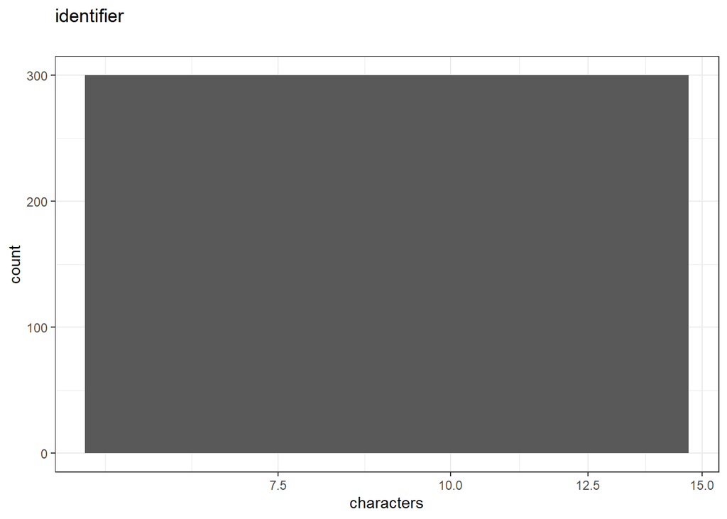

Distribution of values for identifier

0 missing values.

#### Summary statistics

| name | data_type | n_missing | complete_rate | n_unique | empty | min | max | whitespace | label |
| --- | --- | --- | --- | --- | --- | --- | --- | --- | --- |
| identifier | character | 0 | 1 | 150 | 0 | 9 | 9 | 0 | NA |

### jatosStudyResultId

#### Distribution

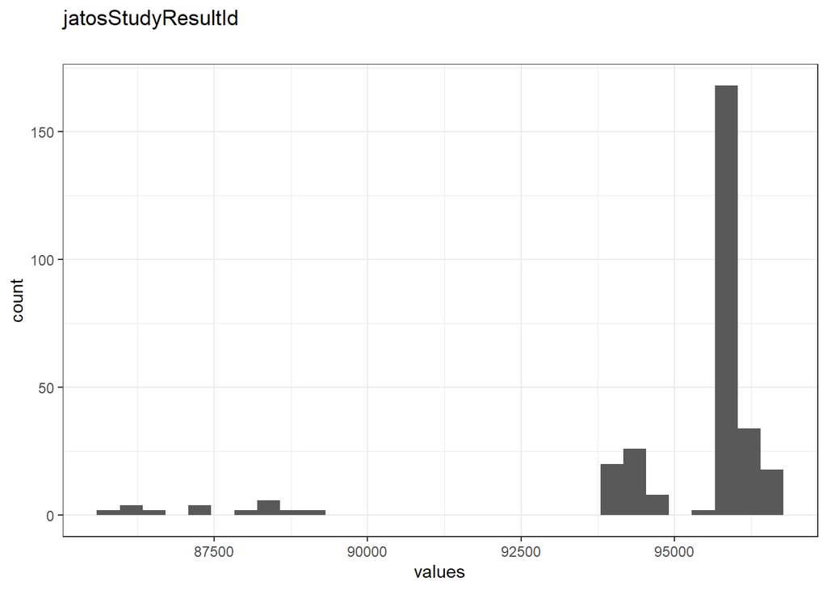

Distribution of values for jatosStudyResultId

0 missing values.

#### Summary statistics

| name | data_type | n_missing | complete_rate | min | median | max | mean | sd | hist | label |
| --- | --- | --- | --- | --- | --- | --- | --- | --- | --- | --- |
| jatosStudyResultId | numeric | 0 | 1 | 85756 | 95744 | 96571 | 94925.99 | 2312.289 | ▁▁▁▂▇ | NA |

### response

#### Distribution

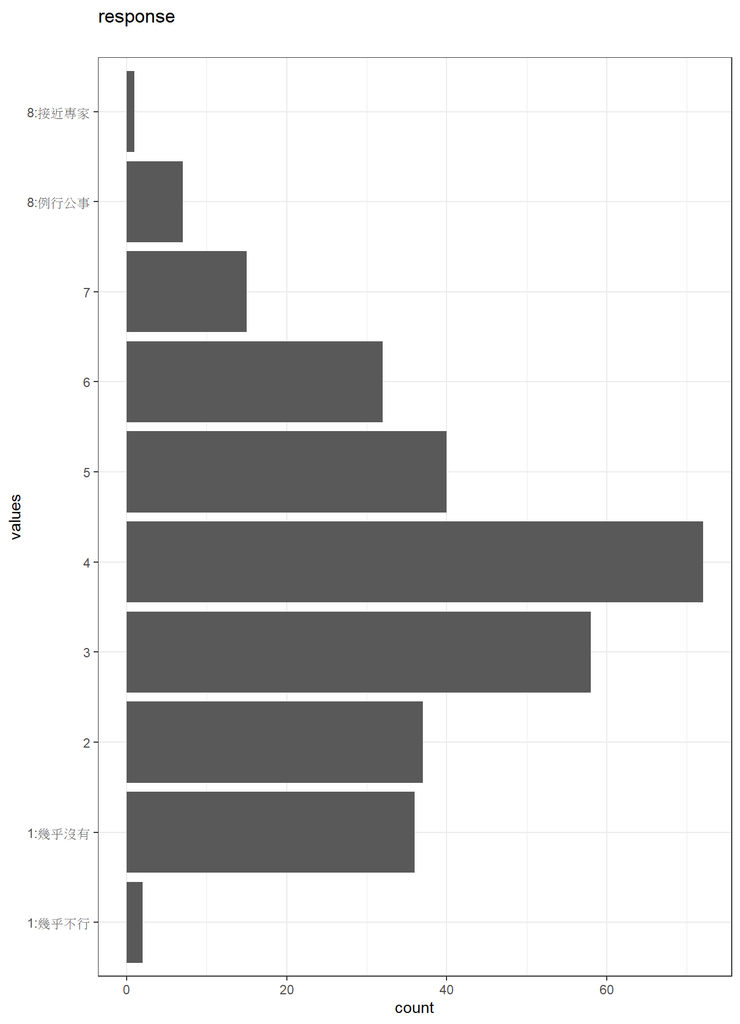

Distribution of values for response

0 missing values.

#### Summary statistics

| name | data_type | n_missing | complete_rate | n_unique | empty | min | max | whitespace | label |
| --- | --- | --- | --- | --- | --- | --- | --- | --- | --- |
| response | character | 0 | 1 | 10 | 0 | 1 | 6 | 0 | NA |

## Missingness report

## codebook: post survey

```r
codebook(df_Post,metadata_table = FALSE, metadata_json = FALSE)
```

### Metadata

#### Description

**Dataset name**: df_Post

The dataset has N=10800 rows and 25 columns. 10800 rows have no missing values on any column.

**Metadata for search engines**

- **Date published**: 2022-04-19

| x |
| --- |
| CB |
| CRid01 |
| CRid02 |
| CRid03 |
| CRid04 |
| CRid05 |
| CRid06 |
| Content |
| NH |
| OSA |
| Q_presented |
| Q_type |
| Qid01 |
| Qid02 |
| Qid03 |
| Question |
| Set_id |
| Test_id |
| Topic |
| correct_response |
| identifier |
| jatosStudyResultId |
| response |
| text_order |
| Text_id |

#Variables

### CB

#### Distribution

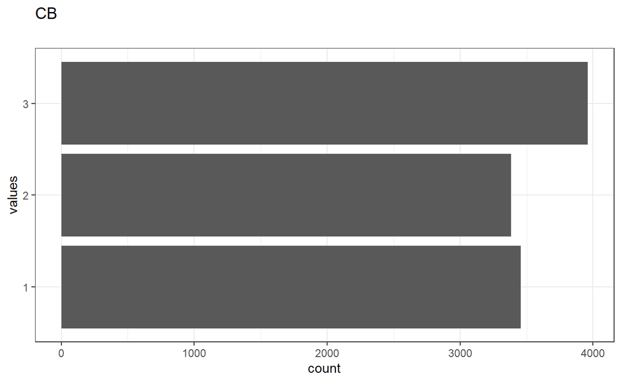

Distribution of values for CB

0 missing values.

#### Summary statistics

| name | data_type | n_missing | complete_rate | n_unique | empty | min | max | whitespace | label |
| --- | --- | --- | --- | --- | --- | --- | --- | --- | --- |
| CB | character | 0 | 1 | 3 | 0 | 1 | 1 | 0 | NA |

### CRid01

#### Distribution

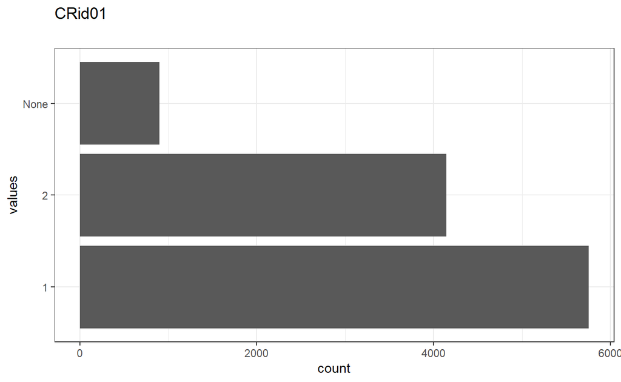

Distribution of values for CRid01

0 missing values.

#### Summary statistics

| name | data_type | n_missing | complete_rate | n_unique | empty | min | max | whitespace | label |
| --- | --- | --- | --- | --- | --- | --- | --- | --- | --- |
| CRid01 | character | 0 | 1 | 3 | 0 | 1 | 4 | 0 | NA |

### CRid02

#### Distribution

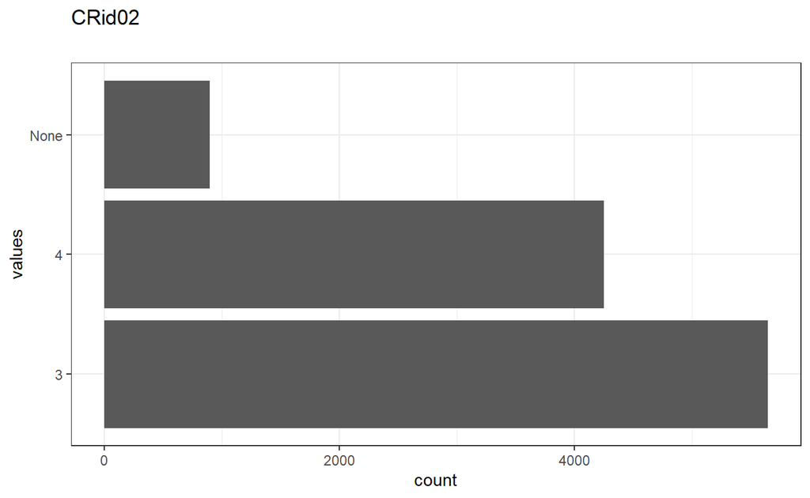

Distribution of values for CRid02

0 missing values.

#### Summary statistics

| name | data_type | n_missing | complete_rate | n_unique | empty | min | max | whitespace | label |
| --- | --- | --- | --- | --- | --- | --- | --- | --- | --- |
| CRid02 | character | 0 | 1 | 3 | 0 | 1 | 4 | 0 | NA |

### CRid03

#### Distribution

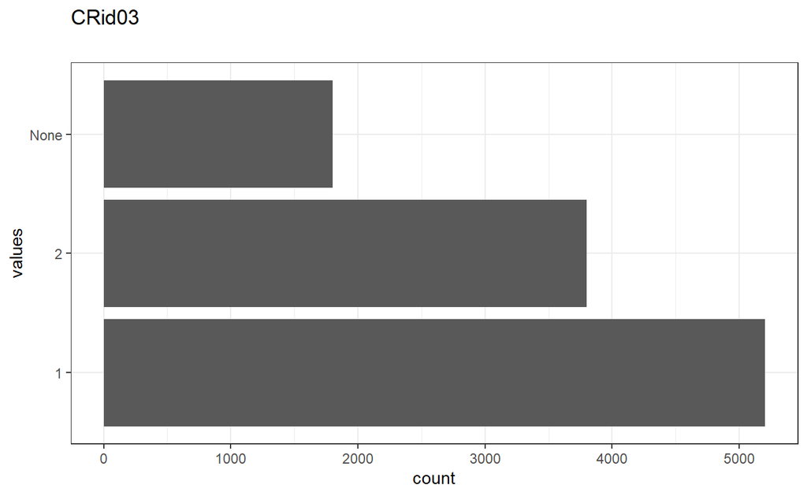

Distribution of values for CRid03

0 missing values.

#### Summary statistics

| name | data_type | n_missing | complete_rate | n_unique | empty | min | max | whitespace | label |
| --- | --- | --- | --- | --- | --- | --- | --- | --- | --- |
| CRid03 | character | 0 | 1 | 3 | 0 | 1 | 4 | 0 | NA |

### CRid04

#### Distribution

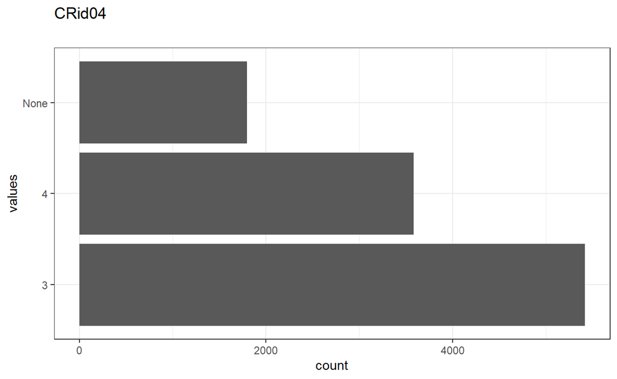

Distribution of values for CRid04

0 missing values.

#### Summary statistics

| name | data_type | n_missing | complete_rate | n_unique | empty | min | max | whitespace | label |
| --- | --- | --- | --- | --- | --- | --- | --- | --- | --- |
| CRid04 | character | 0 | 1 | 3 | 0 | 1 | 4 | 0 | NA |

### CRid05

#### Distribution

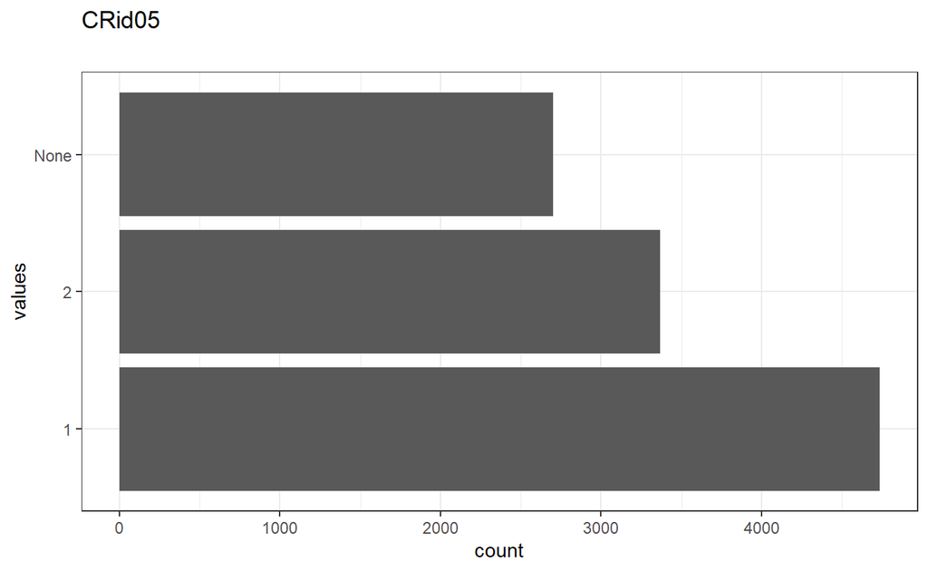

Distribution of values for CRid05

0 missing values.

#### Summary statistics

| name | data_type | n_missing | complete_rate | n_unique | empty | min | max | whitespace | label |
| --- | --- | --- | --- | --- | --- | --- | --- | --- | --- |
| CRid05 | character | 0 | 1 | 3 | 0 | 1 | 4 | 0 | NA |

### CRid06

#### Distribution

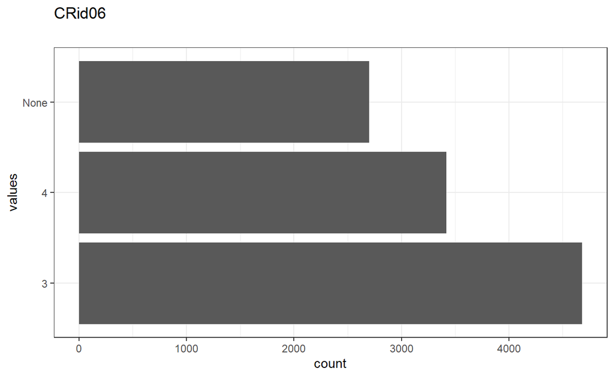

Distribution of values for CRid06

0 missing values.

#### Summary statistics

| name | data_type | n_missing | complete_rate | n_unique | empty | min | max | whitespace | label |
| --- | --- | --- | --- | --- | --- | --- | --- | --- | --- |
| CRid06 | character | 0 | 1 | 3 | 0 | 1 | 4 | 0 | NA |

### Content

#### Distribution

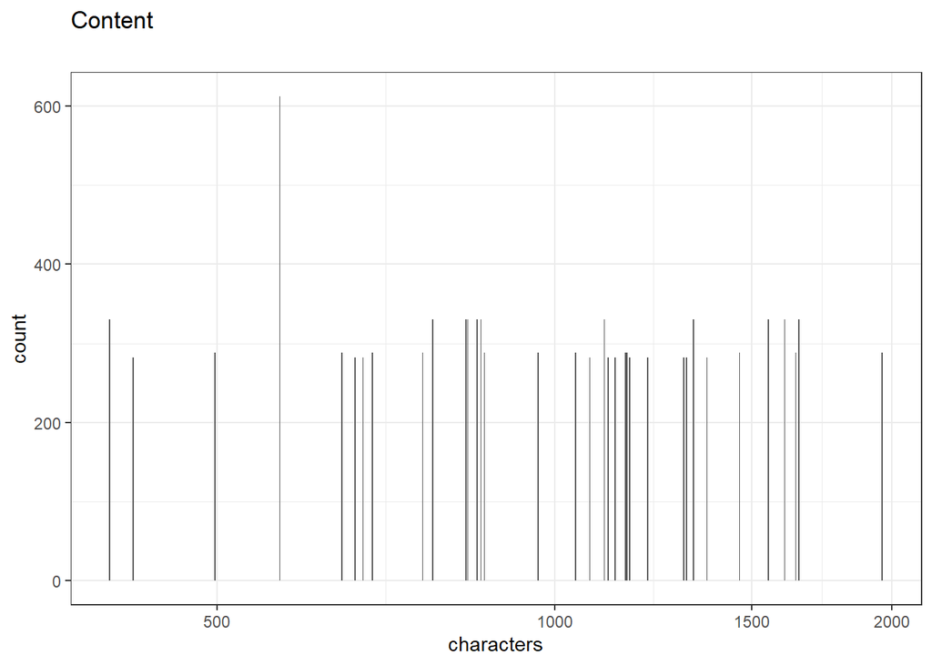

Distribution of values for Content

0 missing values.

#### Summary statistics

| name | data_type | n_missing | complete_rate | n_unique | empty | min | max | whitespace | label |
| --- | --- | --- | --- | --- | --- | --- | --- | --- | --- |
| Content | character | 0 | 1 | 36 | 0 | 401 | 1960 | 0 | NA |

### NH

#### Distribution

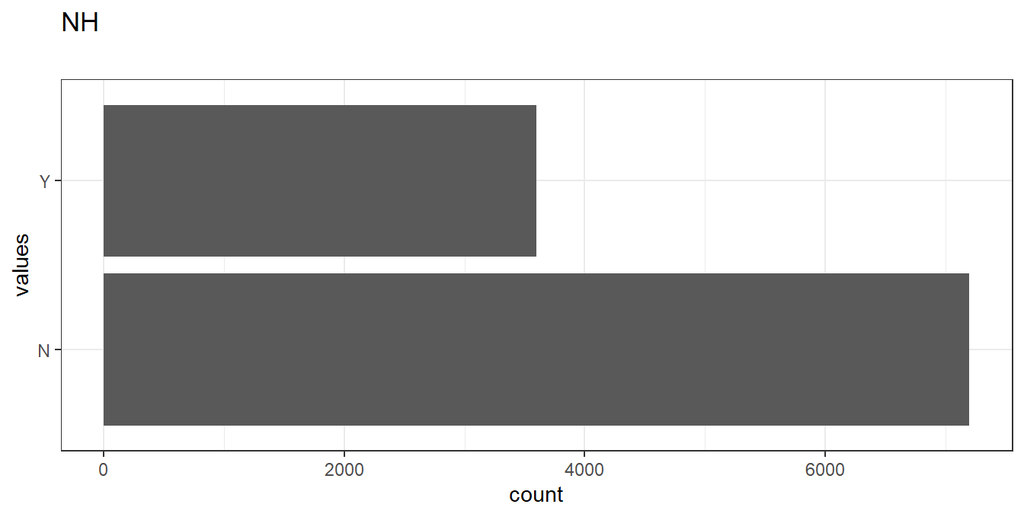

Distribution of values for NH

0 missing values.

#### Summary statistics

| name | data_type | n_missing | complete_rate | n_unique | empty | min | max | whitespace | label |
| --- | --- | --- | --- | --- | --- | --- | --- | --- | --- |
| NH | character | 0 | 1 | 2 | 0 | 1 | 1 | 0 | NA |

### OSA

#### Distribution

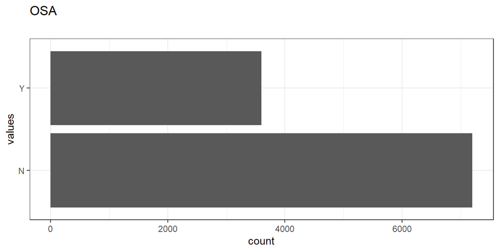

Distribution of values for OSA

0 missing values.

#### Summary statistics

| name | data_type | n_missing | complete_rate | n_unique | empty | min | max | whitespace | label |
| --- | --- | --- | --- | --- | --- | --- | --- | --- | --- |
| OSA | character | 0 | 1 | 2 | 0 | 1 | 1 | 0 | NA |

### Q_presented

#### Distribution

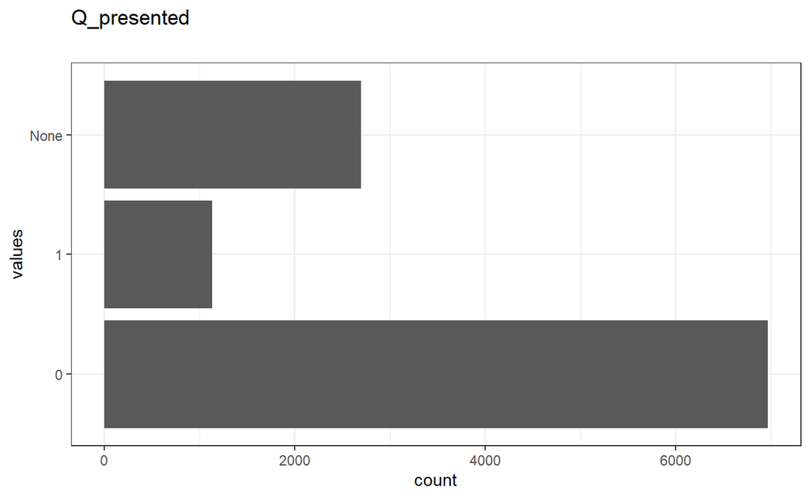

Distribution of values for Q_presented

0 missing values.

#### Summary statistics

| name | data_type | n_missing | complete_rate | n_unique | empty | min | max | whitespace | label |
| --- | --- | --- | --- | --- | --- | --- | --- | --- | --- |
| Q_presented | character | 0 | 1 | 3 | 0 | 1 | 4 | 0 | NA |

### Q_type

#### Distribution

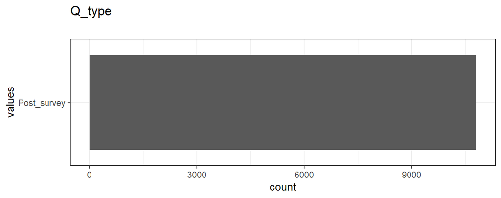

Distribution of values for Q_type

0 missing values.

#### Summary statistics

| name | data_type | n_missing | complete_rate | n_unique | empty | min | max | whitespace | label |
| --- | --- | --- | --- | --- | --- | --- | --- | --- | --- |
| Q_type | character | 0 | 1 | 1 | 0 | 11 | 11 | 0 | NA |

### Qid01

#### Distribution

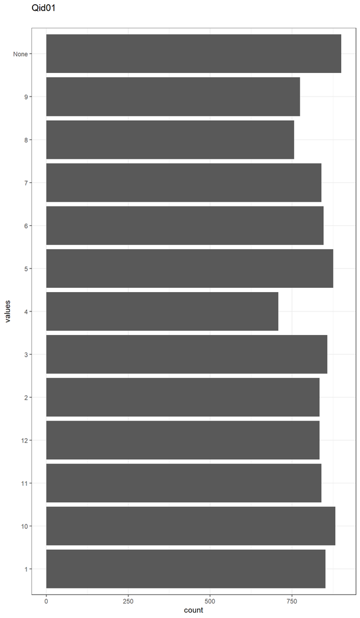

Distribution of values for Qid01

0 missing values.

#### Summary statistics

| name | data_type | n_missing | complete_rate | n_unique | empty | min | max | whitespace | label |
| --- | --- | --- | --- | --- | --- | --- | --- | --- | --- |
| Qid01 | character | 0 | 1 | 13 | 0 | 1 | 4 | 0 | NA |

### Qid02

#### Distribution

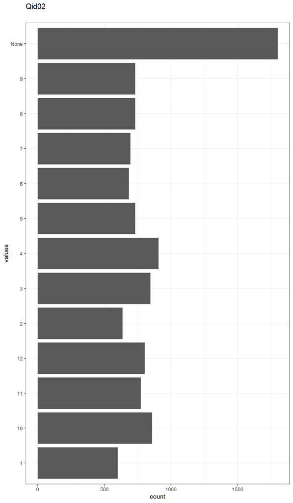

Distribution of values for Qid02

0 missing values.

#### Summary statistics

| name | data_type | n_missing | complete_rate | n_unique | empty | min | max | whitespace | label |
| --- | --- | --- | --- | --- | --- | --- | --- | --- | --- |
| Qid02 | character | 0 | 1 | 13 | 0 | 1 | 4 | 0 | NA |

### Qid03

#### Distribution

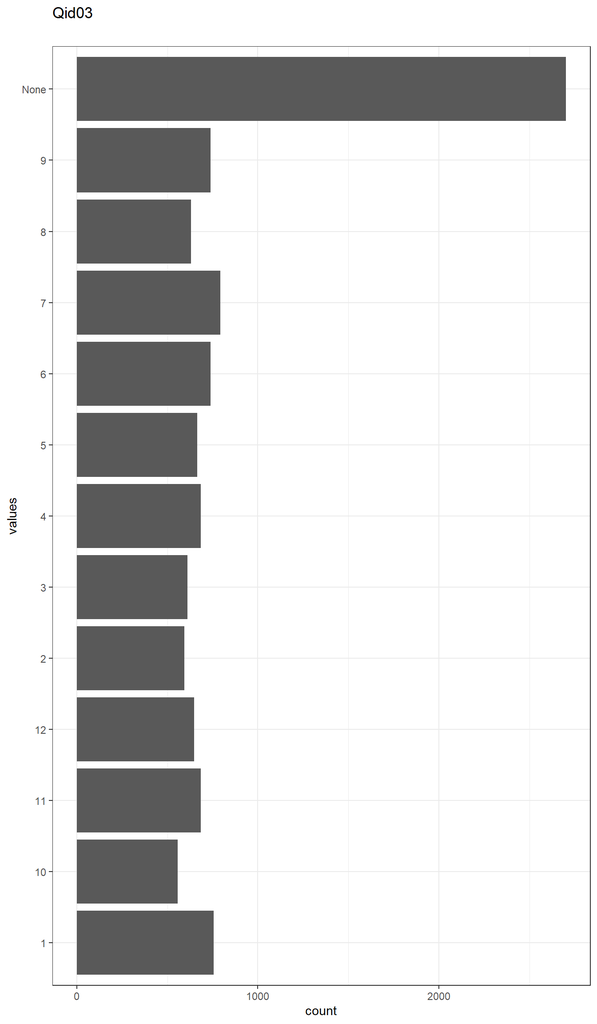

Distribution of values for Qid03

0 missing values.

#### Summary statistics

| name | data_type | n_missing | complete_rate | n_unique | empty | min | max | whitespace | label |
| --- | --- | --- | --- | --- | --- | --- | --- | --- | --- |
| Qid03 | character | 0 | 1 | 13 | 0 | 1 | 4 | 0 | NA |

### Question

#### Distribution

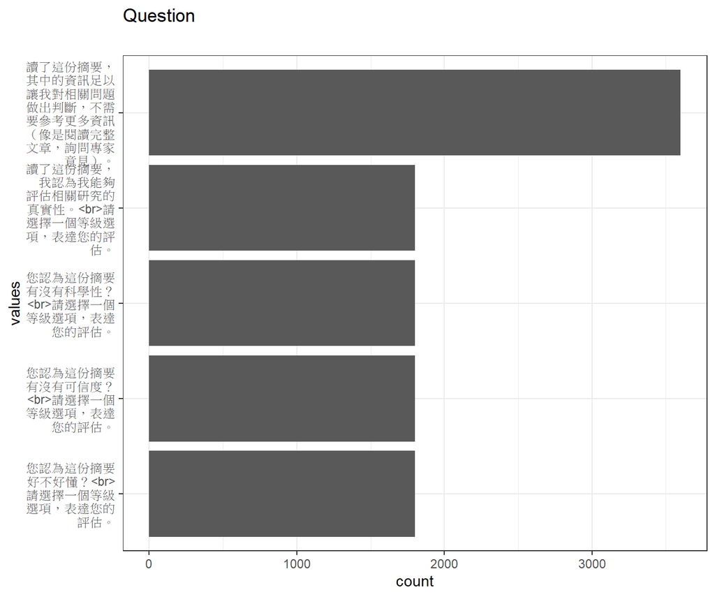

Distribution of values for Question

0 missing values.

#### Summary statistics

| name | data_type | n_missing | complete_rate | n_unique | empty | min | max | whitespace | label |
| --- | --- | --- | --- | --- | --- | --- | --- | --- | --- |
| Question | character | 0 | 1 | 5 | 0 | 33 | 54 | 0 | NA |

### Set_id

#### Distribution

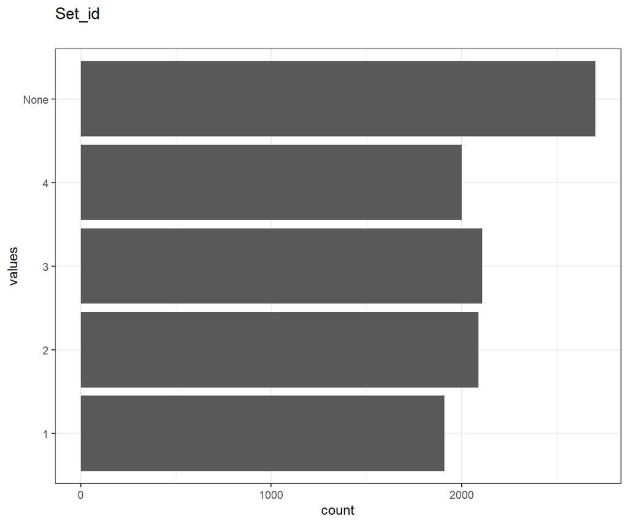

Distribution of values for Set_id

0 missing values.

#### Summary statistics

| name | data_type | n_missing | complete_rate | n_unique | empty | min | max | whitespace | label |
| --- | --- | --- | --- | --- | --- | --- | --- | --- | --- |
| Set_id | character | 0 | 1 | 5 | 0 | 1 | 4 | 0 | NA |

### Test_id

#### Distribution

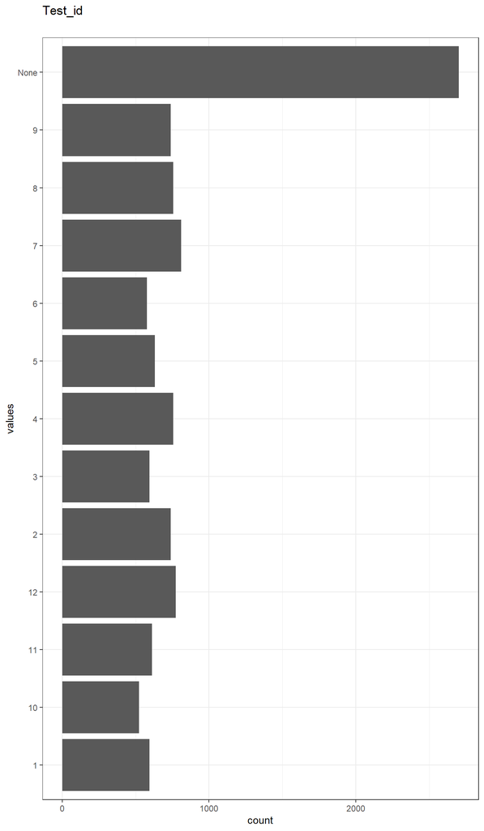

Distribution of values for Test_id

0 missing values.

#### Summary statistics

| name | data_type | n_missing | complete_rate | n_unique | empty | min | max | whitespace | label |
| --- | --- | --- | --- | --- | --- | --- | --- | --- | --- |
| Test_id | character | 0 | 1 | 13 | 0 | 1 | 4 | 0 | NA |

### Topic

#### Distribution

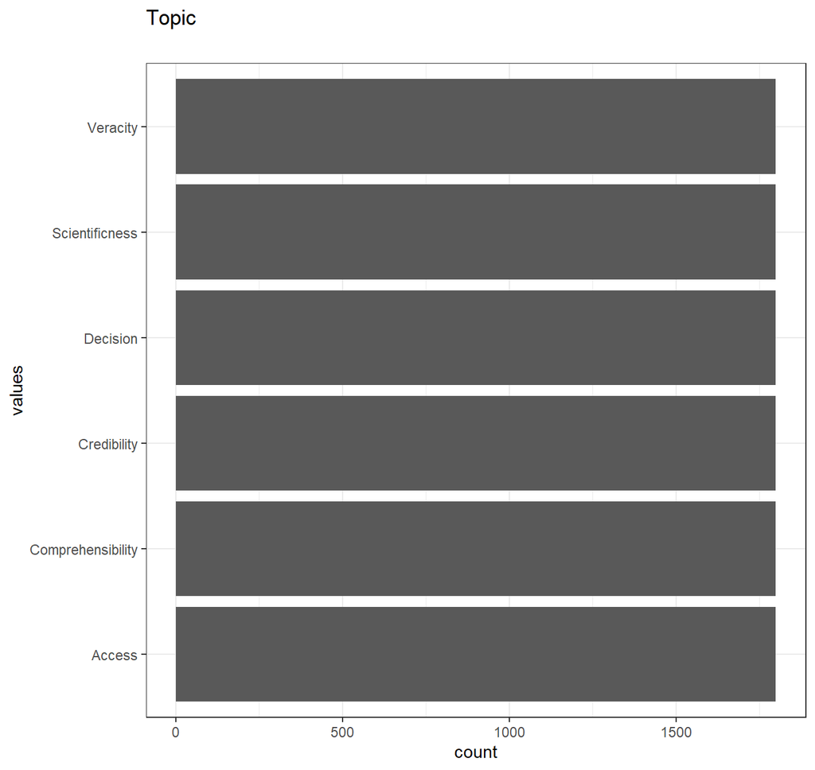

Distribution of values for Topic

0 missing values.

#### Summary statistics

| name | data_type | n_missing | complete_rate | n_unique | empty | min | max | whitespace | label |
| --- | --- | --- | --- | --- | --- | --- | --- | --- | --- |
| Topic | character | 0 | 1 | 6 | 0 | 6 | 17 | 0 | NA |

### correct_response

#### Distribution

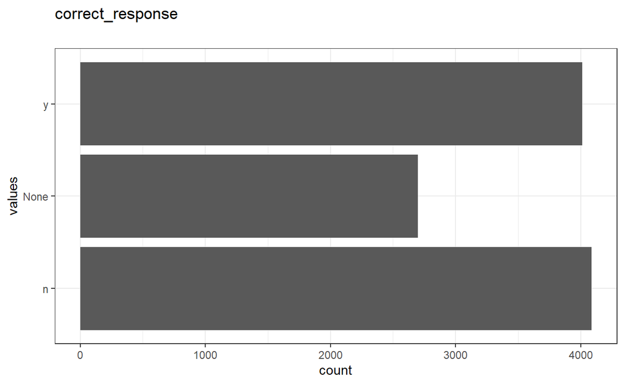

Distribution of values for correct_response

0 missing values.

#### Summary statistics

| name | data_type | n_missing | complete_rate | n_unique | empty | min | max | whitespace | label |
| --- | --- | --- | --- | --- | --- | --- | --- | --- | --- |
| correct_response | character | 0 | 1 | 3 | 0 | 1 | 4 | 0 | NA |

### identifier

#### Distribution

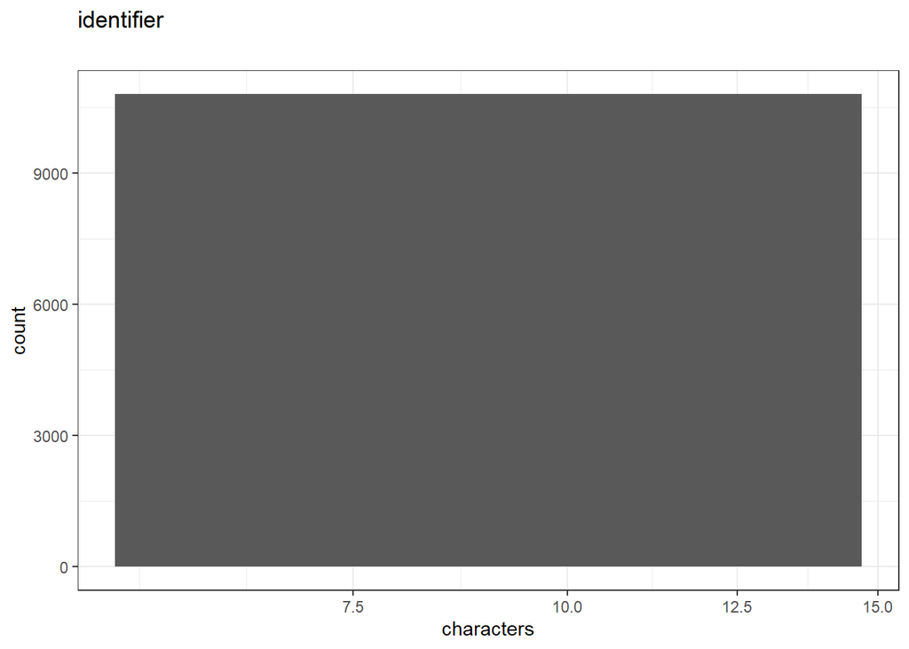

Distribution of values for identifier

0 missing values.

#### Summary statistics

| name | data_type | n_missing | complete_rate | n_unique | empty | min | max | whitespace | label |
| --- | --- | --- | --- | --- | --- | --- | --- | --- | --- |
| identifier | character | 0 | 1 | 150 | 0 | 9 | 9 | 0 | NA |

### jatosStudyResultId

#### Distribution

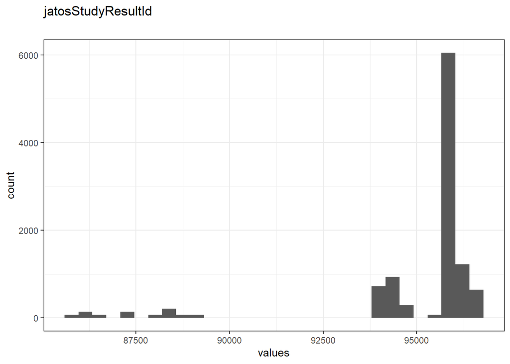

Distribution of values for jatosStudyResultId

0 missing values.

#### Summary statistics

| name | data_type | n_missing | complete_rate | min | median | max | mean | sd | hist | label |
| --- | --- | --- | --- | --- | --- | --- | --- | --- | --- | --- |
| jatosStudyResultId | numeric | 0 | 1 | 85756 | 95744 | 96571 | 94925.99 | 2308.538 | ▁▁▁▂▇ | NA |

### response

#### Distribution

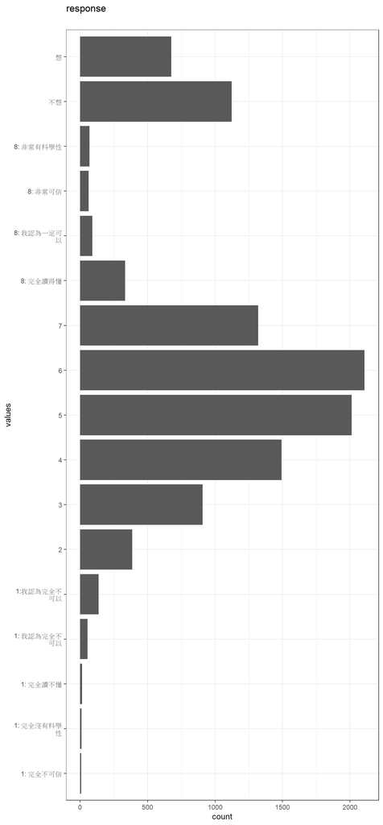

Distribution of values for response

0 missing values.

#### Summary statistics

| name | data_type | n_missing | complete_rate | n_unique | empty | min | max | whitespace | label |
| --- | --- | --- | --- | --- | --- | --- | --- | --- | --- |
| response | character | 0 | 1 | 17 | 0 | 1 | 11 | 0 | NA |

### text_order

#### Distribution

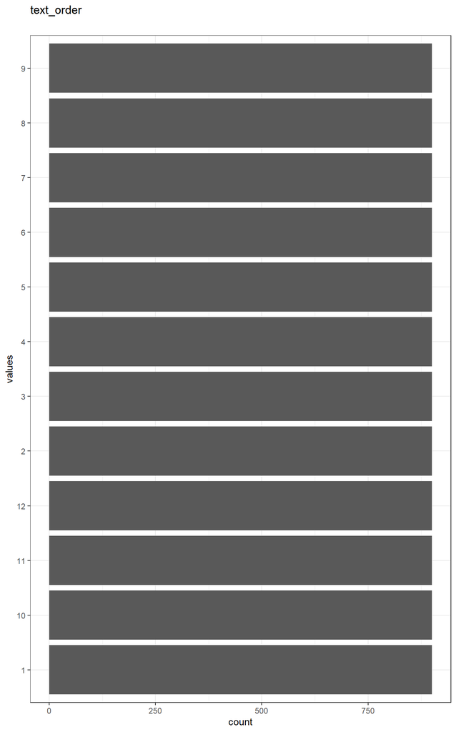

Distribution of values for text_order

0 missing values.

#### Summary statistics

| name | data_type | n_missing | complete_rate | n_unique | empty | min | max | whitespace | label |
| --- | --- | --- | --- | --- | --- | --- | --- | --- | --- |
| text_order | character | 0 | 1 | 12 | 0 | 1 | 2 | 0 | NA |

### Text_id

#### Distribution

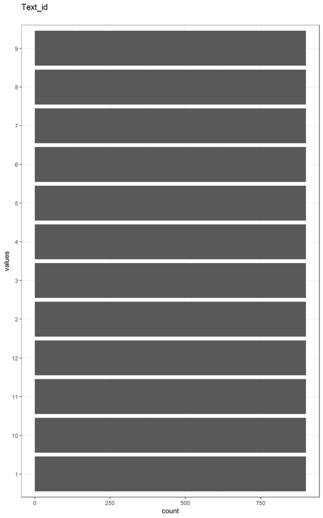

Distribution of values for Text_id

0 missing values.

#### Summary statistics

| name | data_type | n_missing | complete_rate | n_unique | empty | min | max | whitespace | label |
| --- | --- | --- | --- | --- | --- | --- | --- | --- | --- |
| Text_id | character | 0 | 1 | 12 | 0 | 1 | 2 | 0 | NA |

## Missingness report

## codebook: knowledge

```r
codebook(df_knowledge,metadata_table = FALSE, metadata_json = FALSE)
```

### Metadata

#### Description

**Dataset name**: df_knowledge

The dataset has N=28800 rows and 24 columns. 28800 rows have no missing values on any column.

**Metadata for search engines**

- **Date published**: 2022-04-19

| x |
| --- |
| CB |
| CRid01 |
| CRid02 |
| CRid03 |
| CRid04 |
| CRid05 |
| CRid06 |
| Content |
| Q_presented |
| Q_type |
| Qid01 |
| Qid02 |
| Qid03 |
| Question |
| Set_id |
| Test_id |
| Topic |
| correct_response |
| identifier |
| jatosStudyResultId |
| response |
| NH |
| OSA |
| text_order |

#Variables

### CB

#### Distribution

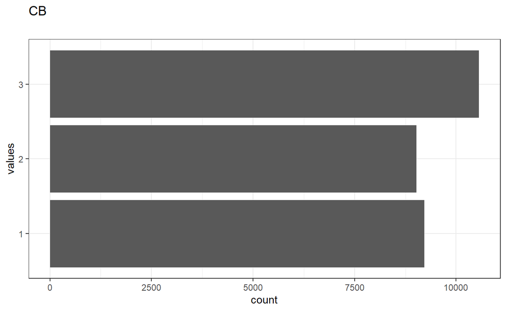

Distribution of values for CB

0 missing values.

#### Summary statistics

| name | data_type | n_missing | complete_rate | n_unique | empty | min | max | whitespace | label |
| --- | --- | --- | --- | --- | --- | --- | --- | --- | --- |
| CB | character | 0 | 1 | 3 | 0 | 1 | 1 | 0 | NA |

### CRid01

#### Distribution

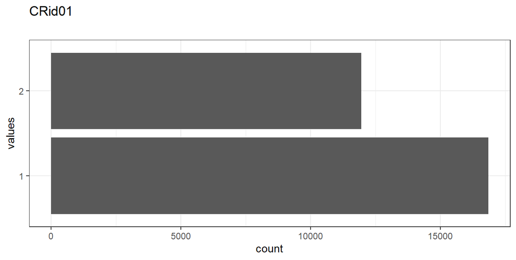

Distribution of values for CRid01

0 missing values.

#### Summary statistics

| name | data_type | n_missing | complete_rate | n_unique | empty | min | max | whitespace | label |
| --- | --- | --- | --- | --- | --- | --- | --- | --- | --- |
| CRid01 | character | 0 | 1 | 2 | 0 | 1 | 1 | 0 | NA |

### CRid02

#### Distribution

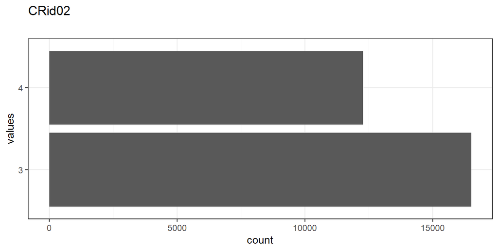

Distribution of values for CRid02

0 missing values.

#### Summary statistics

| name | data_type | n_missing | complete_rate | n_unique | empty | min | max | whitespace | label |
| --- | --- | --- | --- | --- | --- | --- | --- | --- | --- |
| CRid02 | character | 0 | 1 | 2 | 0 | 1 | 1 | 0 | NA |

### CRid03

#### Distribution

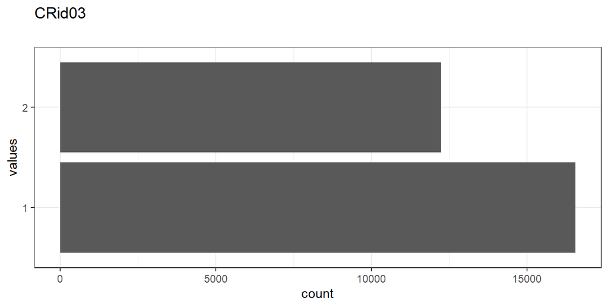

Distribution of values for CRid03

0 missing values.

#### Summary statistics

| name | data_type | n_missing | complete_rate | n_unique | empty | min | max | whitespace | label |
| --- | --- | --- | --- | --- | --- | --- | --- | --- | --- |
| CRid03 | character | 0 | 1 | 2 | 0 | 1 | 1 | 0 | NA |

### CRid04

#### Distribution

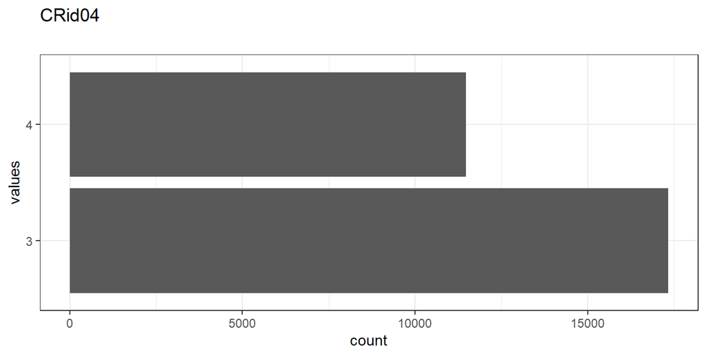

Distribution of values for CRid04

0 missing values.

#### Summary statistics

| name | data_type | n_missing | complete_rate | n_unique | empty | min | max | whitespace | label |
| --- | --- | --- | --- | --- | --- | --- | --- | --- | --- |
| CRid04 | character | 0 | 1 | 2 | 0 | 1 | 1 | 0 | NA |

### CRid05

#### Distribution

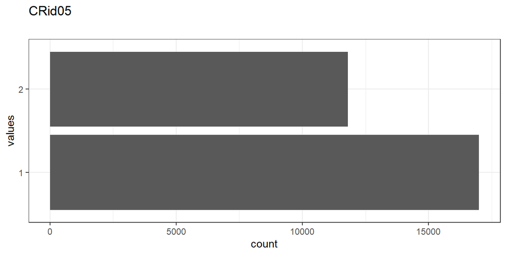

Distribution of values for CRid05

0 missing values.

#### Summary statistics

| name | data_type | n_missing | complete_rate | n_unique | empty | min | max | whitespace | label |
| --- | --- | --- | --- | --- | --- | --- | --- | --- | --- |
| CRid05 | character | 0 | 1 | 2 | 0 | 1 | 1 | 0 | NA |

### CRid06

#### Distribution

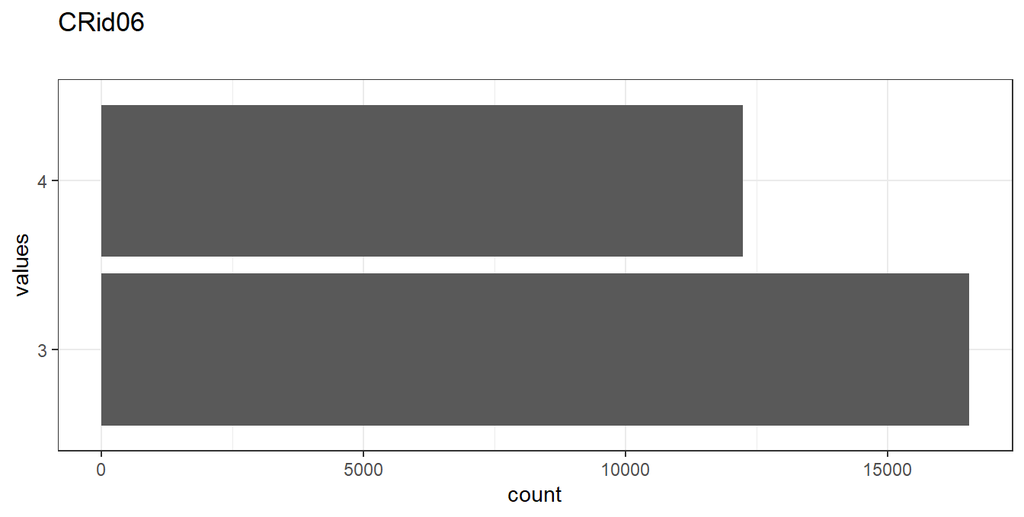

Distribution of values for CRid06

0 missing values.

#### Summary statistics

| name | data_type | n_missing | complete_rate | n_unique | empty | min | max | whitespace | label |
| --- | --- | --- | --- | --- | --- | --- | --- | --- | --- |
| CRid06 | character | 0 | 1 | 2 | 0 | 1 | 1 | 0 | NA |

### Content

#### Distribution

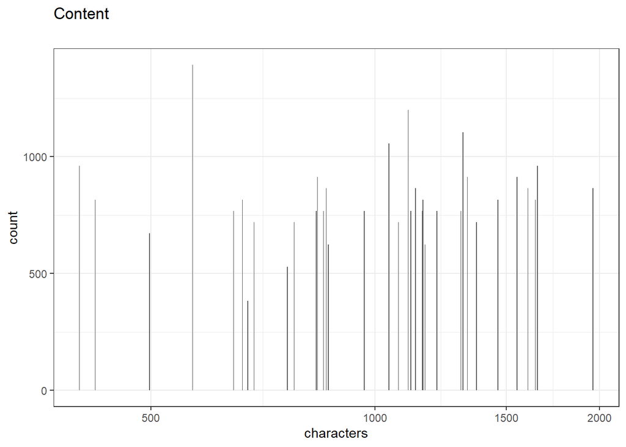

Distribution of values for Content

0 missing values.

#### Summary statistics

| name | data_type | n_missing | complete_rate | n_unique | empty | min | max | whitespace | label |
| --- | --- | --- | --- | --- | --- | --- | --- | --- | --- |
| Content | character | 0 | 1 | 36 | 0 | 401 | 1960 | 0 | NA |

### Q_presented

#### Distribution

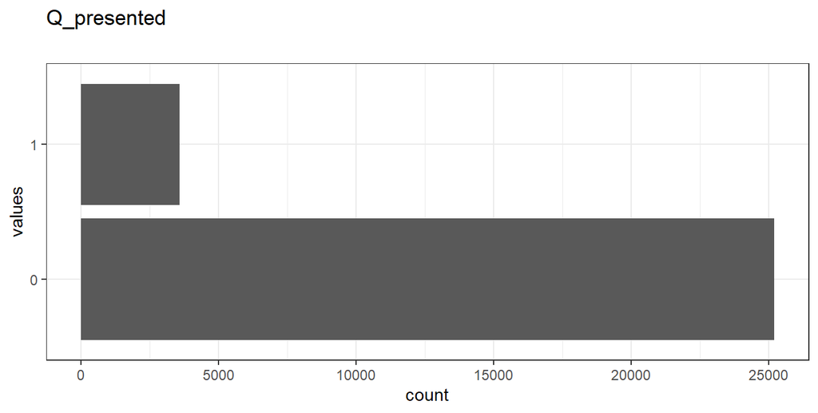

Distribution of values for Q_presented

0 missing values.

#### Summary statistics

| name | data_type | n_missing | complete_rate | n_unique | empty | min | max | whitespace | label |
| --- | --- | --- | --- | --- | --- | --- | --- | --- | --- |
| Q_presented | character | 0 | 1 | 2 | 0 | 1 | 1 | 0 | NA |

### Q_type

#### Distribution

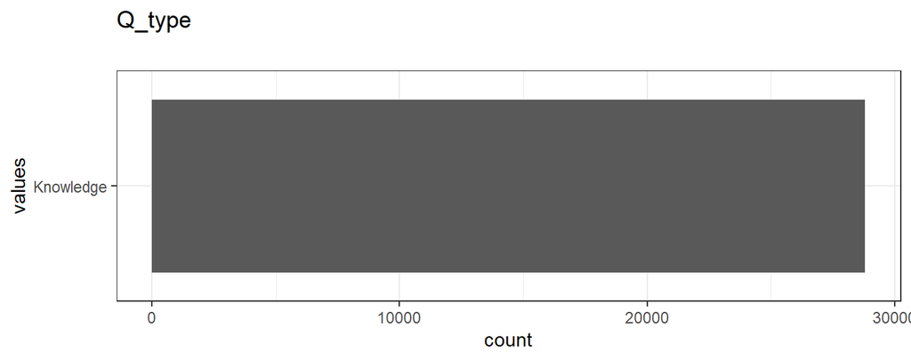

Distribution of values for Q_type

0 missing values.

#### Summary statistics

| name | data_type | n_missing | complete_rate | n_unique | empty | min | max | whitespace | label |
| --- | --- | --- | --- | --- | --- | --- | --- | --- | --- |
| Q_type | character | 0 | 1 | 1 | 0 | 9 | 9 | 0 | NA |

### Qid01

#### Distribution

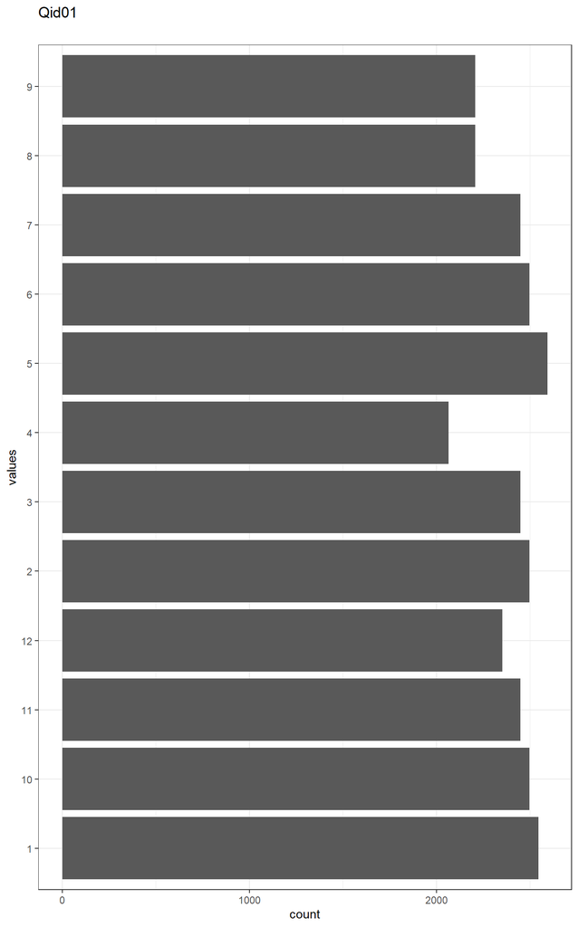

Distribution of values for Qid01

0 missing values.

#### Summary statistics

| name | data_type | n_missing | complete_rate | n_unique | empty | min | max | whitespace | label |
| --- | --- | --- | --- | --- | --- | --- | --- | --- | --- |
| Qid01 | character | 0 | 1 | 12 | 0 | 1 | 2 | 0 | NA |

### Qid02

#### Distribution

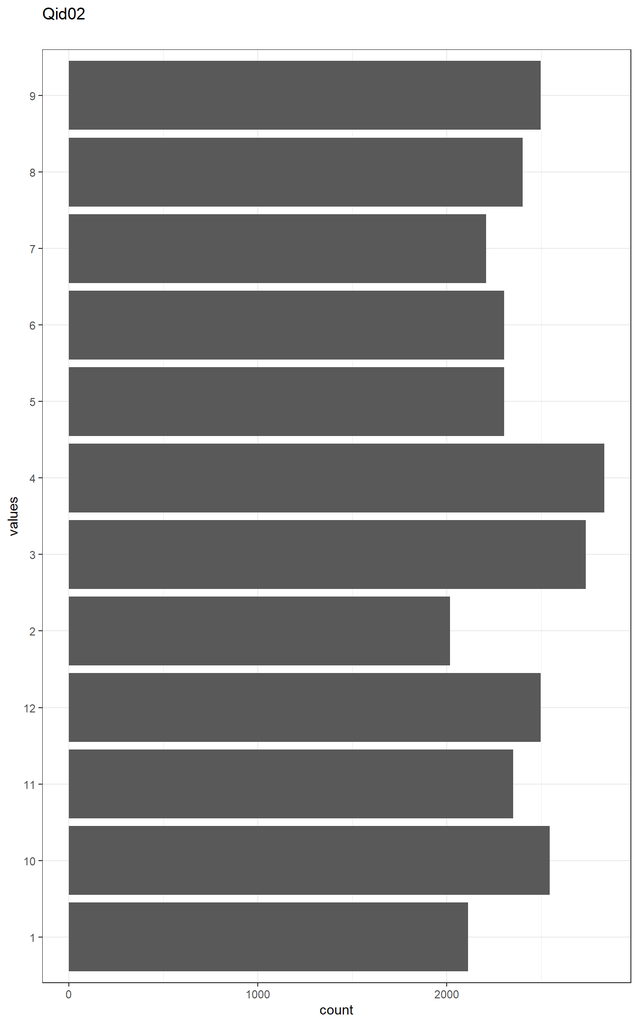

Distribution of values for Qid02

0 missing values.

#### Summary statistics

| name | data_type | n_missing | complete_rate | n_unique | empty | min | max | whitespace | label |
| --- | --- | --- | --- | --- | --- | --- | --- | --- | --- |
| Qid02 | character | 0 | 1 | 12 | 0 | 1 | 2 | 0 | NA |

### Qid03

#### Distribution

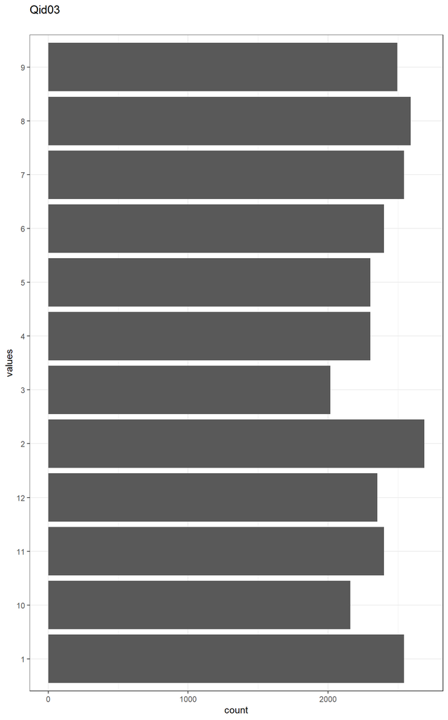

Distribution of values for Qid03

0 missing values.

#### Summary statistics

| name | data_type | n_missing | complete_rate | n_unique | empty | min | max | whitespace | label |
| --- | --- | --- | --- | --- | --- | --- | --- | --- | --- |
| Qid03 | character | 0 | 1 | 12 | 0 | 1 | 2 | 0 | NA |

### Question

#### Distribution

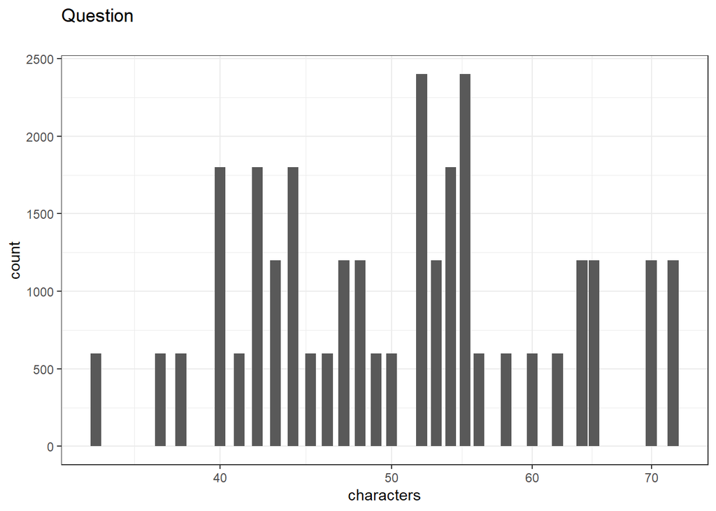

Distribution of values for Question

0 missing values.

#### Summary statistics

| name | data_type | n_missing | complete_rate | n_unique | empty | min | max | whitespace | label |
| --- | --- | --- | --- | --- | --- | --- | --- | --- | --- |
| Question | character | 0 | 1 | 47 | 0 | 34 | 72 | 0 | NA |

### Set_id

#### Distribution

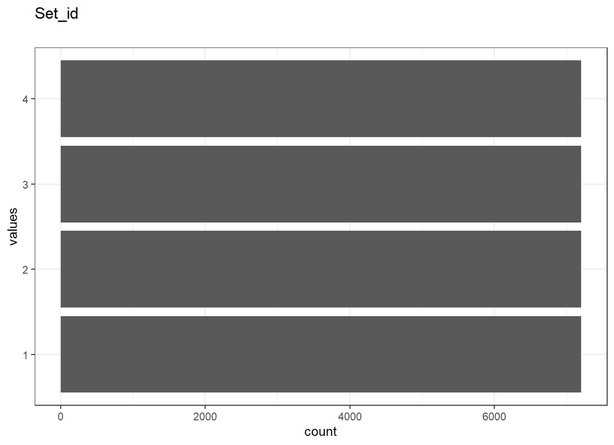

Distribution of values for Set_id

0 missing values.

#### Summary statistics

| name | data_type | n_missing | complete_rate | n_unique | empty | min | max | whitespace | label |
| --- | --- | --- | --- | --- | --- | --- | --- | --- | --- |
| Set_id | character | 0 | 1 | 4 | 0 | 1 | 1 | 0 | NA |

### Test_id

#### Distribution

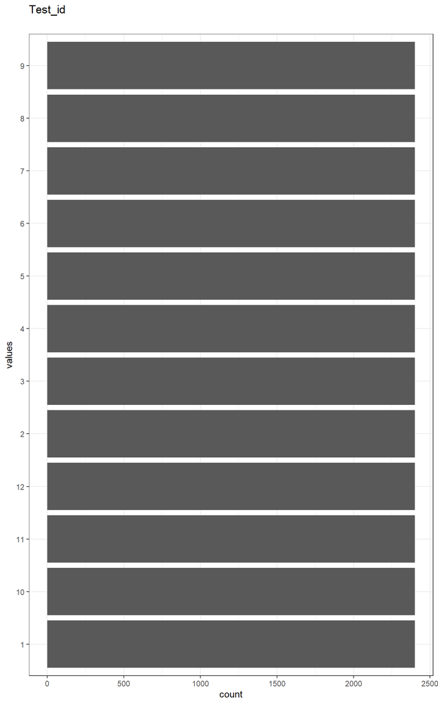

Distribution of values for Test_id

0 missing values.

#### Summary statistics

| name | data_type | n_missing | complete_rate | n_unique | empty | min | max | whitespace | label |
| --- | --- | --- | --- | --- | --- | --- | --- | --- | --- |
| Test_id | character | 0 | 1 | 12 | 0 | 1 | 2 | 0 | NA |

### Topic

#### Distribution

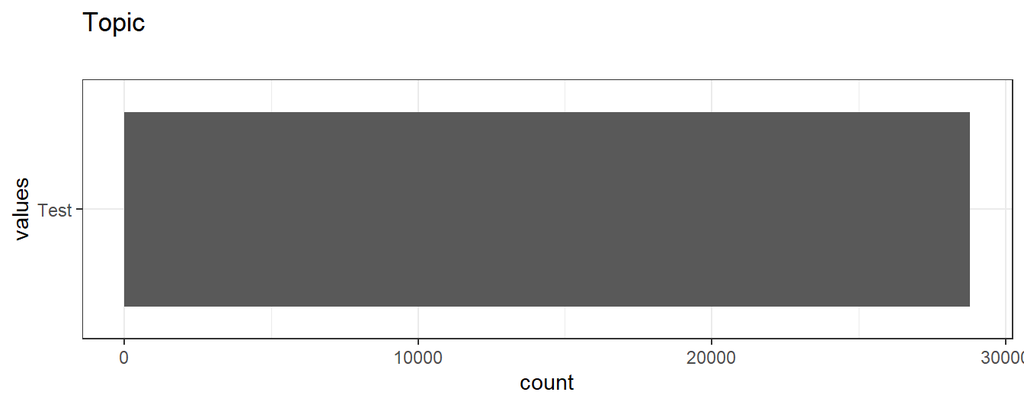

Distribution of values for Topic

0 missing values.

#### Summary statistics

| name | data_type | n_missing | complete_rate | n_unique | empty | min | max | whitespace | label |
| --- | --- | --- | --- | --- | --- | --- | --- | --- | --- |
| Topic | character | 0 | 1 | 1 | 0 | 4 | 4 | 0 | NA |

### correct_response

#### Distribution

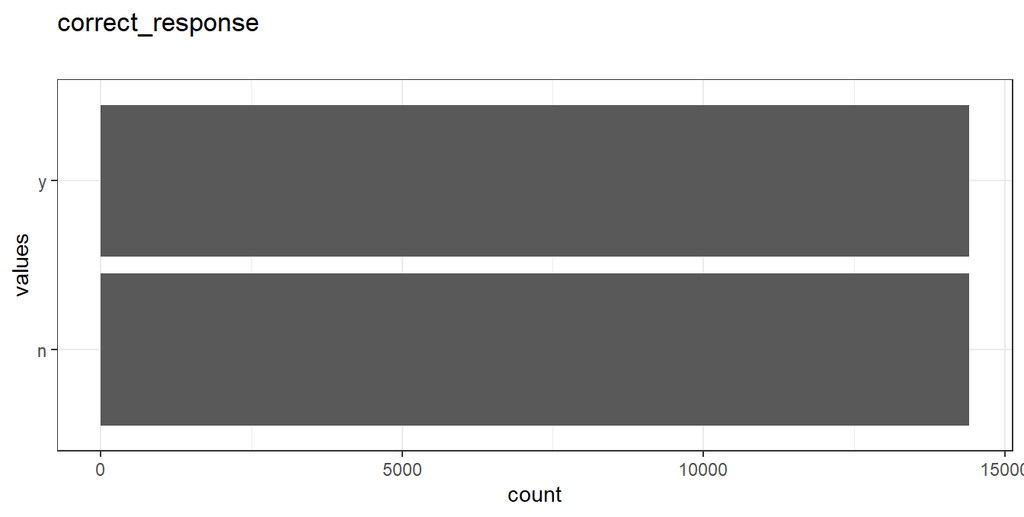

Distribution of values for correct_response

0 missing values.

#### Summary statistics

| name | data_type | n_missing | complete_rate | n_unique | empty | min | max | whitespace | label |
| --- | --- | --- | --- | --- | --- | --- | --- | --- | --- |
| correct_response | character | 0 | 1 | 2 | 0 | 1 | 1 | 0 | NA |

### identifier

#### Distribution

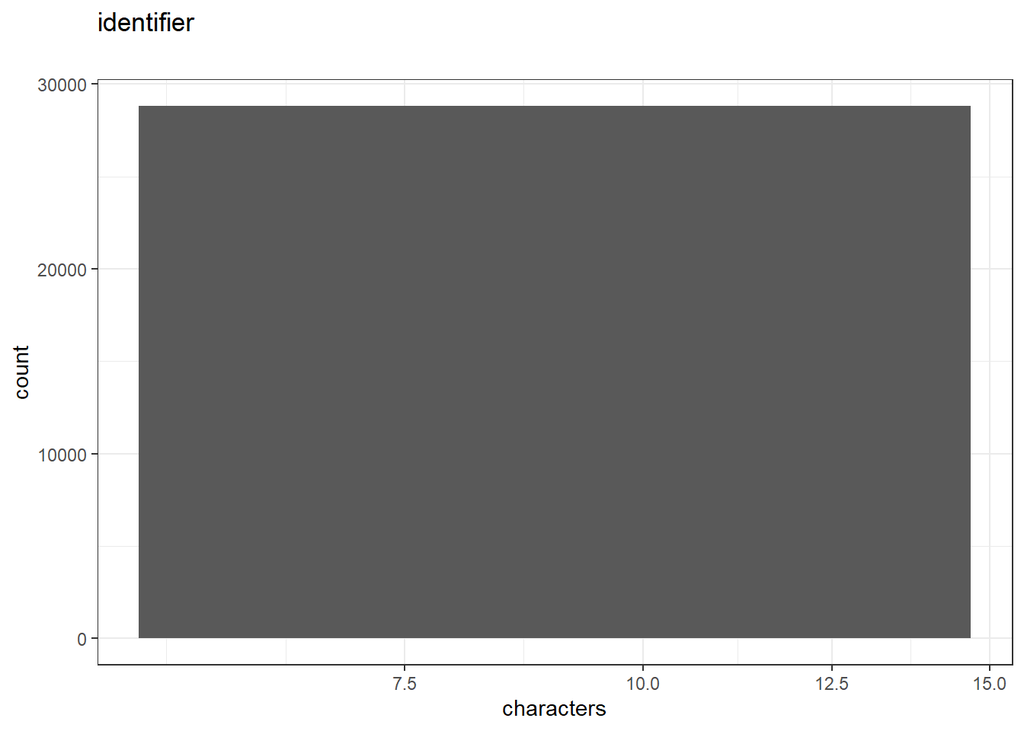

Distribution of values for identifier

0 missing values.

#### Summary statistics

| name | data_type | n_missing | complete_rate | n_unique | empty | min | max | whitespace | label |
| --- | --- | --- | --- | --- | --- | --- | --- | --- | --- |
| identifier | character | 0 | 1 | 150 | 0 | 9 | 9 | 0 | NA |

### jatosStudyResultId

#### Distribution

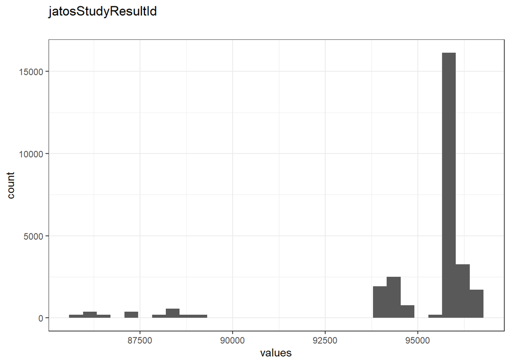

Distribution of values for jatosStudyResultId

0 missing values.

#### Summary statistics

| name | data_type | n_missing | complete_rate | min | median | max | mean | sd | hist | label |
| --- | --- | --- | --- | --- | --- | --- | --- | --- | --- | --- |
| jatosStudyResultId | numeric | 0 | 1 | 85756 | 95744 | 96571 | 94925.99 | 2308.472 | ▁▁▁▂▇ | NA |

### response

#### Distribution

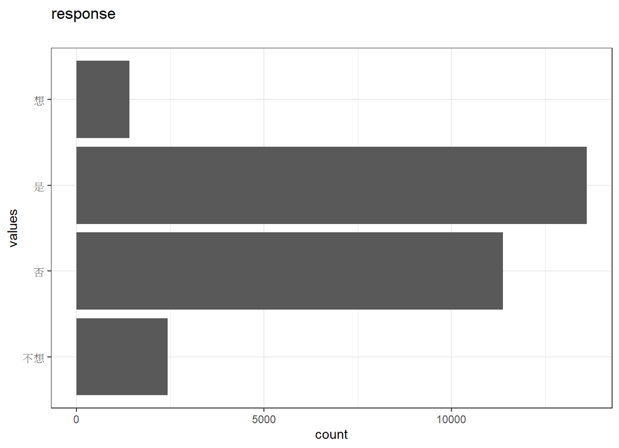

Distribution of values for response

0 missing values.

#### Summary statistics

| name | data_type | n_missing | complete_rate | n_unique | empty | min | max | whitespace | label |
| --- | --- | --- | --- | --- | --- | --- | --- | --- | --- |
| response | character | 0 | 1 | 4 | 0 | 1 | 2 | 0 | NA |

### NH

#### Distribution

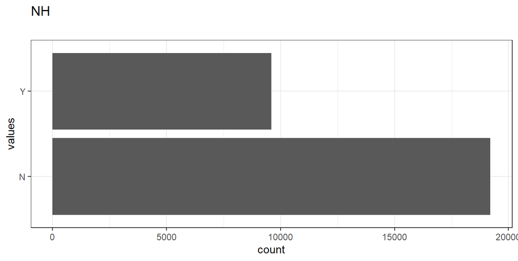

Distribution of values for NH

0 missing values.

#### Summary statistics

| name | data_type | n_missing | complete_rate | n_unique | empty | min | max | whitespace | label |
| --- | --- | --- | --- | --- | --- | --- | --- | --- | --- |
| NH | character | 0 | 1 | 2 | 0 | 1 | 1 | 0 | NA |